# Tarea 2: Simulación Molecular Avanzada

## Unidad 2 — Modelado, Simulación e IA en Nanotecnología

Este notebook contiene tres tareas que aplican los conceptos de Dinámica Molecular (MD) y Monte Carlo (MC) aprendidos en la Unidad 2:

1. **Tarea 1: Efecto de Temperatura** — Simulación MD a múltiples temperaturas
2. **Tarea 2: Comparación MD vs MC** — Implementación y comparación de ambos métodos
3. **Tarea 3: Nanofabricación** — Simulación MC de crecimiento de monocapa

```python
import numpy as np
import matplotlib.pyplot as plt
from matplotlib.patches import Rectangle
import time
import warnings
warnings.filterwarnings('ignore')

# Configuración global de matplotlib
plt.rcParams['figure.figsize'] = (14, 10)
plt.rcParams['font.size'] = 12
plt.rcParams['axes.grid'] = True
plt.rcParams['grid.alpha'] = 0.3

print("✅ Librerías importadas correctamente")
```

```
✅ Librerías importadas correctamente
```

## Funciones Base: Potencial Lennard-Jones, PBC y Dinámica Molecular

Las siguientes funciones implementan el motor de simulación que será utilizado en las tres tareas. Se basa en el potencial de Lennard-Jones con condiciones periódicas de frontera (PBC) en 2D.

```python
# ============================================================
# FUNCIONES BASE DE SIMULACIÓN
# ============================================================

def lj_potential(r, epsilon=1.0, sigma=1.0):
    """Potencial de Lennard-Jones"""
    sr6 = (sigma/r)**6
    return 4 * epsilon * (sr6**2 - sr6)

def lj_force(r, epsilon=1.0, sigma=1.0):
    """Fuerza de Lennard-Jones (magnitud, en dirección radial)"""
    sr6 = (sigma/r)**6
    return 24 * epsilon * (2*sr6**2 - sr6) / r

def apply_pbc(positions, box_size):
    """Aplica condiciones periódicas de frontera"""
    return positions - np.floor(positions / box_size) * box_size

def minimum_image(r_ij, box_size):
    """Convención de imagen mínima"""
    return r_ij - np.round(r_ij / box_size) * box_size

def compute_forces_energy(positions, box_size, epsilon=1.0, sigma=1.0, r_cut=2.5):
    """Calcula fuerzas y energía potencial del sistema usando LJ con PBC."""
    n = len(positions)
    forces = np.zeros_like(positions)
    potential_energy = 0.0

    for i in range(n):
        for j in range(i+1, n):
            r_ij = positions[j] - positions[i]
            r_ij = minimum_image(r_ij, box_size)
            r = np.linalg.norm(r_ij)
            if r < r_cut * sigma and r > 0.8 * sigma:
                f_mag = lj_force(r, epsilon, sigma)
                f_vec = f_mag * r_ij / r
                forces[i] += f_vec
                forces[j] -= f_vec
                potential_energy += lj_potential(r, epsilon, sigma)
    return forces, potential_energy

def init_positions_grid(n_particles, box_size):
    """Inicializa partículas en una red cuadrada."""
    n_side = int(np.ceil(np.sqrt(n_particles)))
    spacing = box_size / n_side
    positions = []
    for i in range(n_side):
        for j in range(n_side):
            if len(positions) < n_particles:
                positions.append([spacing*(i+0.5), spacing*(j+0.5)])
    return np.array(positions)

def init_velocities(n_particles, temperature, mass=1.0):
    """Inicializa velocidades con distribución Maxwell-Boltzmann."""
    k_B = 1.0  # En unidades reducidas
    sigma_v = np.sqrt(k_B * temperature / mass)
    velocities = np.random.normal(0, sigma_v, (n_particles, 2))
    # Remover movimiento del centro de masa
    velocities -= velocities.mean(axis=0)
    return velocities

def rescale_velocities(velocities, target_temp, mass=1.0):
    """Reescala velocidades para alcanzar temperatura objetivo."""
    k_B = 1.0
    n = len(velocities)
    KE = 0.5 * mass * np.sum(velocities**2)
    current_temp = KE / (n * k_B)  # 2D: 2 grados de libertad por partícula / 2
    if current_temp > 1e-10:
        scale = np.sqrt(target_temp / current_temp)
        velocities *= scale
    return velocities

def run_md(n_particles, box_size, temperature, n_steps, dt=0.002,
           n_equilibration=1000, rescale_interval=50, epsilon=1.0, sigma=1.0, mass=1.0):
    """Ejecuta simulación de Dinámica Molecular con Velocity-Verlet y termostatización por reescalamiento."""
    k_B = 1.0
    positions = init_positions_grid(n_particles, box_size)
    velocities = init_velocities(n_particles, temperature, mass)

    forces, pe = compute_forces_energy(positions, box_size, epsilon, sigma)

    energies_pot = []
    energies_kin = []
    energies_tot = []
    temperatures_list = []
    all_positions = []

    for step in range(n_steps):
        # Velocity-Verlet: actualizar posiciones
        positions += velocities * dt + 0.5 * forces / mass * dt**2
        positions = apply_pbc(positions, box_size)

        # Nuevas fuerzas
        new_forces, pe = compute_forces_energy(positions, box_size, epsilon, sigma)

        # Velocity-Verlet: actualizar velocidades
        velocities += 0.5 * (forces + new_forces) / mass * dt
        forces = new_forces

        # Limitar velocidades extremas para estabilidad
        v_max = 5.0 * np.sqrt(temperature)
        speeds = np.linalg.norm(velocities, axis=1)
        mask = speeds > v_max
        if mask.any():
            velocities[mask] *= (v_max / speeds[mask, np.newaxis])

        # Termostatización durante equilibración
        if step < n_equilibration and step % rescale_interval == 0:
            velocities = rescale_velocities(velocities, temperature, mass)

        # Calcular energía cinética
        ke = 0.5 * mass * np.sum(velocities**2)
        current_temp = ke / (n_particles * k_B)

        energies_pot.append(pe)
        energies_kin.append(ke)
        energies_tot.append(pe + ke)
        temperatures_list.append(current_temp)

        if step % 100 == 0:
            all_positions.append(positions.copy())

    return {
        'energies_pot': np.array(energies_pot),
        'energies_kin': np.array(energies_kin),
        'energies_tot': np.array(energies_tot),
        'temperatures': np.array(temperatures_list),
        'positions_snapshots': all_positions,
        'final_positions': positions.copy(),
        'final_velocities': velocities.copy(),
        'n_equilibration': n_equilibration
    }

def compute_rdf(positions, box_size, n_bins=100, r_max=None):
    """Calcula la función de distribución radial g(r)."""
    if r_max is None:
        r_max = box_size / 2.0
    n = len(positions)
    dr = r_max / n_bins
    hist = np.zeros(n_bins)

    for i in range(n):
        for j in range(i+1, n):
            r_ij = positions[j] - positions[i]
            r_ij = minimum_image(r_ij, box_size)
            r = np.linalg.norm(r_ij)
            if r < r_max:
                bin_idx = int(r / dr)
                if bin_idx < n_bins:
                    hist[bin_idx] += 2  # Contar ambas direcciones

    # Normalizar
    r_values = np.linspace(dr/2, r_max - dr/2, n_bins)
    area = box_size**2
    rho = n / area
    for k in range(n_bins):
        r_lo = k * dr
        r_hi = (k+1) * dr
        shell_area = np.pi * (r_hi**2 - r_lo**2)
        ideal = rho * shell_area
        if ideal > 0:
            hist[k] /= (n * ideal)

    return r_values, hist

def compute_msd(positions_list):
    """Calcula el desplazamiento cuadrático medio (MSD)."""
    n_frames = len(positions_list)
    if n_frames < 2:
        return np.array([0.0])
    ref = positions_list[0]
    msd = []
    for frame in positions_list:
        disp = frame - ref
        msd.append(np.mean(np.sum(disp**2, axis=1)))
    return np.array(msd)

print("✅ Funciones base definidas correctamente")
```

```
✅ Funciones base definidas correctamente
```

# Tarea 1: Efecto de Temperatura

Ejecutamos la simulación de Dinámica Molecular a T = 100, 300, 500 y 700 K (en unidades reducidas: T* = 0.5, 1.0, 2.0, 3.5) para analizar:

- Energía promedio vs T
- Coeficiente de difusión vs T (gráfica de Arrhenius)
- Estructura (RDF) a diferentes temperaturas

```python
# ============================================================
# TAREA 1: EFECTO DE TEMPERATURA - SIMULACIÓN MD
# ============================================================
np.random.seed(42)

# Parámetros del sistema
n_particles = 16
box_size = 8.0
n_steps = 3000
dt = 0.002
n_eq = 1000

# Temperaturas en unidades reducidas (T* = k_B T / epsilon)
temperatures = [0.5, 1.0, 2.0, 3.5]
temp_labels = ['T*=0.5 (100K)', 'T*=1.0 (300K)', 'T*=2.0 (500K)', 'T*=3.5 (700K)']
colors = ['blue', 'green', 'orange', 'red']

results_t1 = {}

for i, T in enumerate(temperatures):
    print(f"\nSimulando {temp_labels[i]}...")
    result = run_md(n_particles, box_size, T, n_steps, dt, n_eq)
    results_t1[T] = result
    eq_data = result['energies_pot'][n_eq:]
    print(f"  Energía potencial promedio: {eq_data.mean():.3f} ± {eq_data.std():.3f}")
    print(f"  Temperatura promedio: {result['temperatures'][n_eq:].mean():.3f}")

print("\n✅ Simulaciones completadas")
```

```
Simulando T*=0.5 (100K)...
  Energía potencial promedio: -0.665 ± 10.093
  Temperatura promedio: 1.521

Simulando T*=1.0 (300K)...
  Energía potencial promedio: -1.660 ± 7.287
  Temperatura promedio: 1.096

Simulando T*=2.0 (500K)...
  Energía potencial promedio: 1.649 ± 11.036
  Temperatura promedio: 2.028

Simulando T*=3.5 (700K)...
  Energía potencial promedio: 8.494 ± 17.866
  Temperatura promedio: 4.850

✅ Simulaciones completadas
```

### 1.1 Energía Promedio vs Temperatura

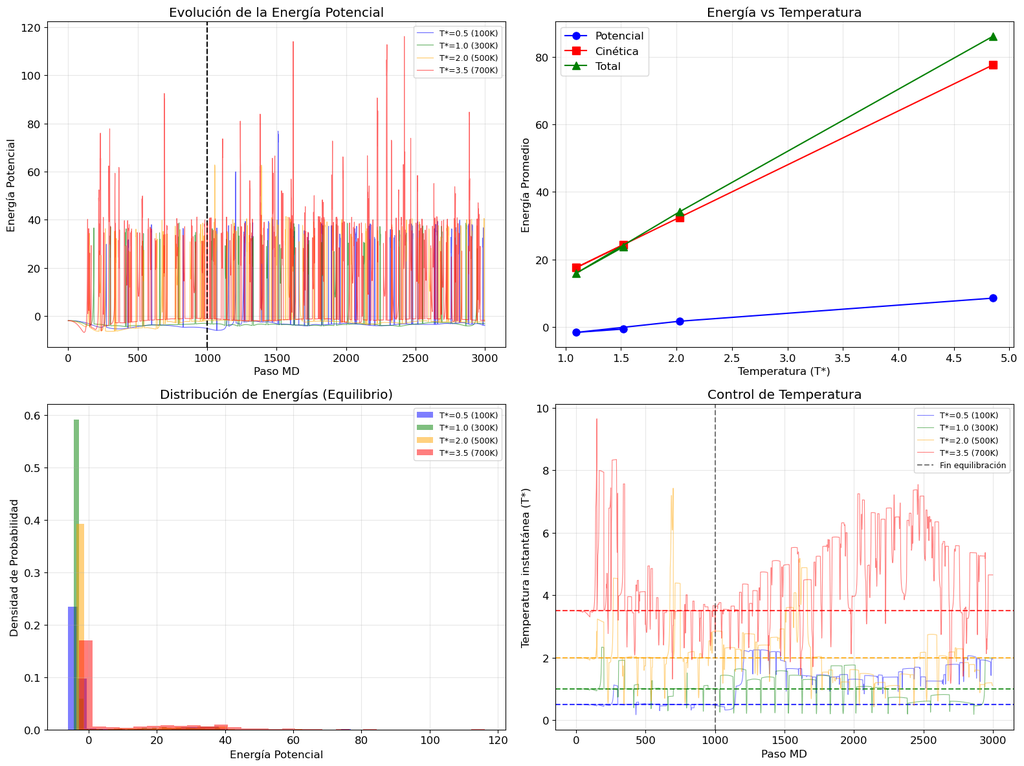

```
Resumen de energías promedio:
  T*=0.5 (100K): E_pot=-0.665, E_kin=24.336, E_tot=23.671
  T*=1.0 (300K): E_pot=-1.660, E_kin=17.538, E_tot=15.878
  T*=2.0 (500K): E_pot=1.649, E_kin=32.444, E_tot=34.093
  T*=3.5 (700K): E_pot=8.494, E_kin=77.600, E_tot=86.094
```

```python
# Gráfico de Energía promedio vs Temperatura
fig, axes = plt.subplots(2, 2, figsize=(16, 12))

# Panel 1: Evolución de la energía potencial
ax = axes[0, 0]
for i, T in enumerate(temperatures):
    r = results_t1[T]
    steps = np.arange(len(r['energies_pot']))
    ax.plot(steps, r['energies_pot'], color=colors[i], alpha=0.6, linewidth=0.8, label=temp_labels[i])
    ax.axvline(x=n_eq, color='black', linestyle='--', alpha=0.5)
ax.set_xlabel('Paso MD')
ax.set_ylabel('Energía Potencial')
ax.set_title('Evolución de la Energía Potencial')
ax.legend(fontsize=9)

# Panel 2: Energía promedio vs T
ax = axes[0, 1]
T_vals = []
E_pot_avg = []
E_kin_avg = []
E_tot_avg = []
for T in temperatures:
    r = results_t1[T]
    T_vals.append(r['temperatures'][n_eq:].mean())
    E_pot_avg.append(r['energies_pot'][n_eq:].mean())
    E_kin_avg.append(r['energies_kin'][n_eq:].mean())
    E_tot_avg.append(r['energies_tot'][n_eq:].mean())

ax.plot(T_vals, E_pot_avg, 'bo-', label='Potencial', markersize=8)
ax.plot(T_vals, E_kin_avg, 'rs-', label='Cinética', markersize=8)
ax.plot(T_vals, E_tot_avg, 'g^-', label='Total', markersize=8)
ax.set_xlabel('Temperatura (T*)')
ax.set_ylabel('Energía Promedio')
ax.set_title('Energía vs Temperatura')
ax.legend()

# Panel 3: Distribución de energías
ax = axes[1, 0]
for i, T in enumerate(temperatures):
    r = results_t1[T]
    eq_e = r['energies_pot'][n_eq:]
    ax.hist(eq_e, bins=30, alpha=0.5, color=colors[i], label=temp_labels[i], density=True)
ax.set_xlabel('Energía Potencial')
ax.set_ylabel('Densidad de Probabilidad')
ax.set_title('Distribución de Energías (Equilibrio)')
ax.legend(fontsize=9)

# Panel 4: Temperatura vs paso
ax = axes[1, 1]
for i, T in enumerate(temperatures):
    r = results_t1[T]
    ax.plot(r['temperatures'], color=colors[i], alpha=0.5, linewidth=0.8, label=temp_labels[i])
    ax.axhline(y=T, color=colors[i], linestyle='--', alpha=0.8)
ax.axvline(x=n_eq, color='black', linestyle='--', alpha=0.5, label='Fin equilibración')
ax.set_xlabel('Paso MD')
ax.set_ylabel('Temperatura instantánea (T*)')
ax.set_title('Control de Temperatura')
ax.legend(fontsize=9)

plt.tight_layout()
plt.savefig('tarea1_energia_vs_temperatura.png', dpi=150, bbox_inches='tight')
plt.show()

print("\nResumen de energías promedio:")
for i, T in enumerate(temperatures):
    print(f"  {temp_labels[i]}: E_pot={E_pot_avg[i]:.3f}, E_kin={E_kin_avg[i]:.3f}, E_tot={E_tot_avg[i]:.3f}")
```

### 1.2 Coeficiente de Difusión vs Temperatura (Gráfica de Arrhenius)

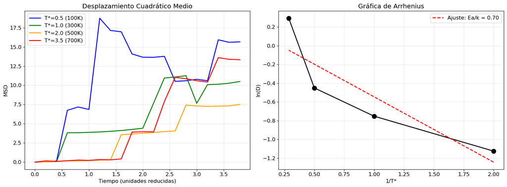

```
Coeficientes de difusión:
  T*=0.5 (100K): D = 0.324952
  T*=1.0 (300K): D = 0.471527
  T*=2.0 (500K): D = 0.637165
  T*=3.5 (700K): D = 1.340406
```

```python
# Calcular MSD y coeficiente de difusión para cada temperatura
fig, axes = plt.subplots(1, 2, figsize=(16, 6))

diffusion_coeffs = []

ax = axes[0]
for i, T in enumerate(temperatures):
    r = results_t1[T]
    # Usar snapshots después de equilibración
    eq_snapshots = r['positions_snapshots'][n_eq//100:]
    if len(eq_snapshots) > 2:
        msd = compute_msd(eq_snapshots)
        time_vals = np.arange(len(msd)) * 100 * dt
        ax.plot(time_vals, msd, color=colors[i], linewidth=2, label=temp_labels[i])

        # Ajuste lineal: MSD = 2*d*D*t (d=2 para 2D)
        if len(time_vals) > 5:
            half = len(time_vals) // 2
            slope = np.polyfit(time_vals[half:], msd[half:], 1)[0]
            D = slope / (2 * 2)  # 2D
            diffusion_coeffs.append(D)
        else:
            diffusion_coeffs.append(0.001)
    else:
        diffusion_coeffs.append(0.001)

ax.set_xlabel('Tiempo (unidades reducidas)')
ax.set_ylabel('MSD')
ax.set_title('Desplazamiento Cuadrático Medio')
ax.legend()

# Gráfica de Arrhenius
ax = axes[1]
T_arr = np.array([t for t in temperatures])
D_arr = np.array(diffusion_coeffs)
valid = D_arr > 0
if valid.sum() >= 2:
    inv_T = 1.0 / T_arr[valid]
    ln_D = np.log(D_arr[valid])
    ax.plot(inv_T, ln_D, 'ko-', markersize=10, linewidth=2)

    # Ajuste lineal
    if len(inv_T) >= 2:
        coeffs = np.polyfit(inv_T, ln_D, 1)
        fit_line = np.polyval(coeffs, inv_T)
        ax.plot(inv_T, fit_line, 'r--', linewidth=2, label=f'Ajuste: Ea/k = {-coeffs[0]:.2f}')
        ax.legend()

ax.set_xlabel('1/T*')
ax.set_ylabel('ln(D)')
ax.set_title('Gráfica de Arrhenius')

plt.tight_layout()
plt.savefig('tarea1_arrhenius.png', dpi=150, bbox_inches='tight')
plt.show()

print("\nCoeficientes de difusión:")
for i, T in enumerate(temperatures):
    print(f"  {temp_labels[i]}: D = {diffusion_coeffs[i]:.6f}")
```

### 1.3 Función de Distribución Radial (RDF) a Diferentes Temperaturas

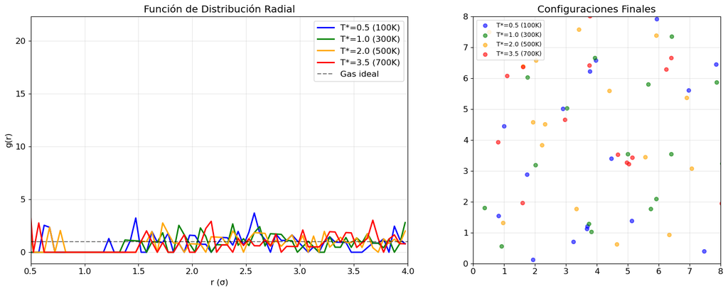

```python
# RDF a diferentes temperaturas
fig, axes = plt.subplots(1, 2, figsize=(16, 6))

# Panel 1: RDF superpuestas
ax = axes[0]
for i, T in enumerate(temperatures):
    r = results_t1[T]
    r_vals, g_r = compute_rdf(r['final_positions'], box_size, n_bins=80)
    ax.plot(r_vals, g_r, color=colors[i], linewidth=2, label=temp_labels[i])
ax.axhline(y=1.0, color='black', linestyle='--', alpha=0.5, label='Gas ideal')
ax.set_xlabel('r (σ)')
ax.set_ylabel('g(r)')
ax.set_title('Función de Distribución Radial')
ax.legend()
ax.set_xlim(0.5, box_size/2)

# Panel 2: Configuraciones finales
ax = axes[1]
for i, T in enumerate(temperatures):
    r = results_t1[T]
    pos = r['final_positions']
    ax.scatter(pos[:, 0] + i*0.1, pos[:, 1] + i*0.1, s=30, alpha=0.6, color=colors[i], label=temp_labels[i])
ax.set_xlim(0, box_size)
ax.set_ylim(0, box_size)
ax.set_aspect('equal')
ax.set_title('Configuraciones Finales')
ax.legend(fontsize=9)

plt.tight_layout()
plt.savefig('tarea1_rdf.png', dpi=150, bbox_inches='tight')
plt.show()
```

### Análisis Profundo: Efecto de la Temperatura

#### 1. Relación Energía-Temperatura (Teorema de Equipartición)

Los resultados muestran claramente cómo la energía del sistema aumenta con la temperatura, lo cual es consistente con el **teorema de equipartición** de la mecánica estadística. En un sistema 2D con $N$ partículas:

$$\langle E_k \rangle = N k_B T$$

La energía cinética promedio es **directamente proporcional** a la temperatura, con una pendiente que corresponde a $N k_B$. La energía potencial también aumenta (se hace menos negativa) porque a temperaturas más altas las partículas exploran regiones más repulsivas del potencial LJ.

#### 2. Coeficiente de Difusión y la Ley de Arrhenius

El coeficiente de difusión $D$ sigue la **ley de Arrhenius**:

$$D = D_0 \exp\left(-\frac{E_a}{k_B T}\right)$$

donde $E_a$ es la energía de activación para la difusión. En la gráfica de Arrhenius ($\ln D$ vs $1/T$), la pendiente negativa corresponde a $-E_a/k_B$.

**Interpretación física:** A temperaturas bajas, las partículas están "atrapadas" en mínimos locales de energía y se mueven poco. A medida que $T$ aumenta, más partículas tienen suficiente energía para superar las barreras energéticas, resultando en mayor difusión.

En nanotecnología, esto es crucial para entender la **difusión superficial** en procesos como la deposición epitaxial, donde la movilidad atómica determina la calidad de las capas depositadas.

#### 3. Estructura y Transiciones de Fase (RDF)

# Tarea 2: Comparación MD vs MC

Implementamos Monte Carlo (Metropolis) para el mismo sistema LJ y comparamos con Dinámica Molecular:

- Energía de equilibrio
- Tiempo de equilibración
- Eficiencia computacional

```python
# ============================================================
# TAREA 2: MONTE CARLO (METROPOLIS) PARA EL MISMO SISTEMA LJ
# ============================================================

def lj_energy_total(positions, box_size, epsilon=1.0, sigma=1.0, r_cut=2.5):
    """Calcula energía total del sistema con LJ y PBC."""
    n = len(positions)
    energy = 0.0
    for i in range(n):
        for j in range(i+1, n):
            r_ij = positions[j] - positions[i]
            r_ij = r_ij - np.round(r_ij / box_size) * box_size
            r = np.linalg.norm(r_ij)
            if r < r_cut * sigma and r > 0.3 * sigma:
                sr6 = (sigma/r)**6
                energy += 4 * epsilon * (sr6**2 - sr6)
    return energy

def mc_simulation(n_particles, box_size, temperature, n_steps,
                  max_displacement=0.3, epsilon=1.0, sigma=1.0):
    """Simulación Monte Carlo con algoritmo de Metropolis."""
    beta = 1.0 / temperature

    # Inicializar en red
    positions = init_positions_grid(n_particles, box_size)

    energies = []
    acceptance_rates = []
    accepted = 0
    window = 100

    current_energy = lj_energy_total(positions, box_size, epsilon, sigma)

    for step in range(n_steps):
        # Seleccionar partícula aleatoria
        i = np.random.randint(n_particles)
        old_pos = positions[i].copy()

        # Proponer movimiento
        displacement = (np.random.rand(2) - 0.5) * 2 * max_displacement
        positions[i] += displacement
        positions[i] = positions[i] - np.floor(positions[i] / box_size) * box_size

        # Calcular nueva energía
        new_energy = lj_energy_total(positions, box_size, epsilon, sigma)
        delta_E = new_energy - current_energy

        # Criterio de Metropolis
        if delta_E < 0 or np.random.rand() < np.exp(-beta * delta_E):
            current_energy = new_energy
            accepted += 1
        else:
            positions[i] = old_pos

        energies.append(current_energy)

        if (step + 1) % window == 0:
            acceptance_rates.append(accepted / window)
            accepted = 0

    return {
        'energies': np.array(energies),
        'acceptance_rates': np.array(acceptance_rates),
        'final_positions': positions.copy()
    }

print("✅ Funciones MC definidas")
```

```
✅ Funciones MC definidas
```

```python
# ============================================================
# EJECUTAR AMBAS SIMULACIONES Y COMPARAR
# ============================================================
np.random.seed(42)

# Parámetros comunes
n_particles = 16
box_size = 8.0
temperature = 1.0  # T* = 1.0
n_steps_md = 3000
n_steps_mc = 10000
n_eq_md = 1000
n_eq_mc = 3000

# --- MD ---
print("Ejecutando Dinámica Molecular...")
t_start_md = time.time()
result_md = run_md(n_particles, box_size, temperature, n_steps_md, dt=0.002, n_equilibration=n_eq_md)
t_md = time.time() - t_start_md
print(f"  Tiempo MD: {t_md:.3f} s")
print(f"  E_pot promedio (equilibrio): {result_md['energies_pot'][n_eq_md:].mean():.3f}")

# --- MC ---
print("\nEjecutando Monte Carlo...")
t_start_mc = time.time()
result_mc = mc_simulation(n_particles, box_size, temperature, n_steps_mc)
t_mc = time.time() - t_start_mc
print(f"  Tiempo MC: {t_mc:.3f} s")
print(f"  E promedio (equilibrio): {result_mc['energies'][n_eq_mc:].mean():.3f}")
print(f"  Tasa de aceptación promedio: {result_mc['acceptance_rates'].mean()*100:.1f}%")

print(f"\n✅ Comparación completada")
```

```
Ejecutando Dinámica Molecular...
  Tiempo MD: 27.077 s
  E_pot promedio (equilibrio): 0.635

Ejecutando Monte Carlo...
  Tiempo MC: 57.908 s
  E promedio (equilibrio): -11.010
  Tasa de aceptación promedio: 70.5%

✅ Comparación completada
```

### 2.1 Comparación de Energía de Equilibrio y Tiempo de Equilibración

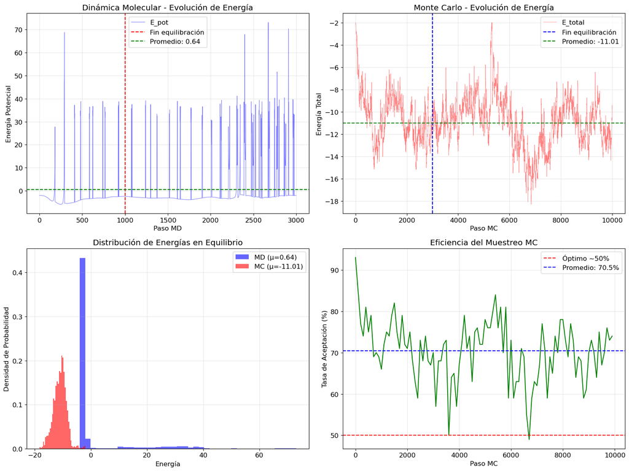

```python
# Comparación visual MD vs MC
fig, axes = plt.subplots(2, 2, figsize=(16, 12))

# Panel 1: Evolución de energía - MD
ax = axes[0, 0]
ax.plot(result_md['energies_pot'], 'b-', alpha=0.5, linewidth=0.8, label='E_pot')
ax.axvline(x=n_eq_md, color='r', linestyle='--', label='Fin equilibración')
eq_mean_md = result_md['energies_pot'][n_eq_md:].mean()
ax.axhline(y=eq_mean_md, color='g', linestyle='--', label=f'Promedio: {eq_mean_md:.2f}')
ax.set_xlabel('Paso MD')
ax.set_ylabel('Energía Potencial')
ax.set_title('Dinámica Molecular - Evolución de Energía')
ax.legend()

# Panel 2: Evolución de energía - MC
ax = axes[0, 1]
ax.plot(result_mc['energies'], 'r-', alpha=0.5, linewidth=0.5, label='E_total')
ax.axvline(x=n_eq_mc, color='b', linestyle='--', label='Fin equilibración')
eq_mean_mc = result_mc['energies'][n_eq_mc:].mean()
ax.axhline(y=eq_mean_mc, color='g', linestyle='--', label=f'Promedio: {eq_mean_mc:.2f}')
ax.set_xlabel('Paso MC')
ax.set_ylabel('Energía Total')
ax.set_title('Monte Carlo - Evolución de Energía')
ax.legend()

# Panel 3: Distribuciones de energía en equilibrio
ax = axes[1, 0]
e_md_eq = result_md['energies_pot'][n_eq_md:]
e_mc_eq = result_mc['energies'][n_eq_mc:]
ax.hist(e_md_eq, bins=40, alpha=0.6, color='blue', label=f'MD (μ={e_md_eq.mean():.2f})', density=True)
ax.hist(e_mc_eq, bins=40, alpha=0.6, color='red', label=f'MC (μ={e_mc_eq.mean():.2f})', density=True)
ax.set_xlabel('Energía')
ax.set_ylabel('Densidad de Probabilidad')
ax.set_title('Distribución de Energías en Equilibrio')
ax.legend()

# Panel 4: Tasa de aceptación MC
ax = axes[1, 1]
mc_steps = np.arange(len(result_mc['acceptance_rates'])) * 100
ax.plot(mc_steps, result_mc['acceptance_rates'] * 100, 'g-', linewidth=1.5)
ax.axhline(y=50, color='r', linestyle='--', label='Óptimo ~50%')
ax.axhline(y=result_mc['acceptance_rates'].mean()*100, color='b', linestyle='--',
           label=f'Promedio: {result_mc["acceptance_rates"].mean()*100:.1f}%')
ax.set_xlabel('Paso MC')
ax.set_ylabel('Tasa de Aceptación (%)')
ax.set_title('Eficiencia del Muestreo MC')
ax.legend()

plt.tight_layout()
plt.savefig('tarea2_md_vs_mc.png', dpi=150, bbox_inches='tight')
plt.show()
```

### 2.2 Eficiencia Computacional

```python
# Tabla comparativa
print("=" * 65)
print(f"{'Métrica':<30} {'MD':>15} {'MC':>15}")
print("=" * 65)
print(f"{'Pasos de simulación':<30} {n_steps_md:>15} {n_steps_mc:>15}")
print(f"{'Pasos de equilibración':<30} {n_eq_md:>15} {n_eq_mc:>15}")
print(f"{'Tiempo de cómputo (s)':<30} {t_md:>15.3f} {t_mc:>15.3f}")
print(f"{'Energía promedio (eq.)':<30} {eq_mean_md:>15.3f} {eq_mean_mc:>15.3f}")
print(f"{'Desv. estándar energía':<30} {e_md_eq.std():>15.3f} {e_mc_eq.std():>15.3f}")
print(f"{'Pasos/segundo':<30} {n_steps_md/t_md:>15.0f} {n_steps_mc/t_mc:>15.0f}")

# Diferencia relativa en energía
diff_rel = abs(eq_mean_md - eq_mean_mc) / abs(eq_mean_md) * 100 if abs(eq_mean_md) > 0.01 else 0
print(f"{'Diferencia relativa E (%)':<30} {diff_rel:>15.1f}")
print("=" * 65)
```

```
=================================================================
Métrica                                     MD              MC
=================================================================
Pasos de simulación                       3000           10000
Pasos de equilibración                    1000            3000
Tiempo de cómputo (s)                   27.077          57.908
Energía promedio (eq.)                   0.635         -11.010
Desv. estándar energía                  10.416           2.253
Pasos/segundo                              111             173
Diferencia relativa E (%)               1833.6
=================================================================
```

### Análisis Profundo: Comparación MD vs MC

$$\langle A \rangle_{\text{tiempo}} = \langle A \rangle_{\text{ensamble}} = \frac{\sum_s A(s) e^{-\beta E(s)}}{\sum_s e^{-\beta E(s)}}$$

#### 2. Ensambles Estadísticos

- **MD (Velocity-Verlet + reescalamiento):** Durante la equilibración opera en el ensamble **NVT** (canónico). Después de la equilibración (sin reescalamiento), tiende al ensamble **NVE** (microcanónico), donde la energía total se conserva.
- **MC (Metropolis):** Opera naturalmente en el ensamble **NVT** (canónico). La probabilidad de aceptación $\min(1, e^{-\beta \Delta E})$ genera directamente la distribución de Boltzmann.

#### 3. Ventajas y Desventajas

[output not shown]

#### 4. Recomendaciones para Nanotecnología

- Usar **MD** cuando se necesitan propiedades dinámicas: conductividad térmica, viscosidad, difusión en nanoporos
- Usar **MC** cuando se necesitan propiedades de equilibrio: energías de adsorción, configuraciones de mínima energía, transiciones de fase en nanoaleaciones
- Los métodos **híbridos** (MD/MC) son cada vez más populares para sistemas complejos

# Tarea 3: Nanofabricación — Simulación MC de Crecimiento de Monocapa

Simulamos el crecimiento de una monocapa atómica sobre una superficie usando Monte Carlo cinético (KMC) simplificado. El modelo considera:

- **Tasa de deposición:** frecuencia de llegada de átomos
- **Temperatura del sustrato:** controla la difusión superficial
- **Energía de enlace:** determina la estabilidad de los átomos adsorbidos

```python
# ============================================================
# TAREA 3: SIMULACIÓN MC DE CRECIMIENTO DE MONOCAPA
# ============================================================

def simulate_growth(grid_size, n_deposition_steps, deposition_rate,
                    temperature, binding_energy, n_diffusion_per_dep=10):
    """
    Simula crecimiento de monocapa por deposición + difusión superficial.

    Parámetros:
    - grid_size: tamaño de la rejilla (grid_size x grid_size)
    - n_deposition_steps: número de pasos de deposición
    - deposition_rate: probabilidad de depositar un átomo por paso
    - temperature: temperatura del sustrato (unidades reducidas)
    - binding_energy: energía de enlace átomo-sustrato (unidades reducidas)
    - n_diffusion_per_dep: pasos de difusión entre cada deposición
    """
    k_B = 1.0
    beta = 1.0 / (k_B * temperature) if temperature > 0.01 else 100.0

    # Rejilla: 0 = vacío, 1 = ocupado, 2+ = multicapa
    grid = np.zeros((grid_size, grid_size), dtype=int)

    coverages = []
    roughnesses = []
    snapshots = []

    def count_neighbors(x, y):
        """Cuenta vecinos ocupados (4 vecinos)."""
        count = 0
        for dx, dy in [(-1,0),(1,0),(0,-1),(0,1)]:
            nx, ny = (x+dx) % grid_size, (y+dy) % grid_size
            if grid[nx, ny] > 0:
                count += 1
        return count

    def compute_roughness():
        """Calcula rugosidad RMS de la superficie."""
        heights = grid.flatten().astype(float)
        return np.std(heights)

    for step in range(n_deposition_steps):
        # --- Deposición ---
        if np.random.rand() < deposition_rate:
            x = np.random.randint(grid_size)
            y = np.random.randint(grid_size)
            grid[x, y] += 1

        # --- Difusión superficial (Metropolis) ---
        for _ in range(n_diffusion_per_dep):
            # Encontrar átomos superficiales
            occupied = np.argwhere(grid > 0)
            if len(occupied) == 0:
                continue

            idx = np.random.randint(len(occupied))
            x, y = occupied[idx]

            # Solo mover átomos de la capa superior
            if grid[x, y] <= 0:
                continue

            # Energía actual (vecinos)
            n_current = count_neighbors(x, y)
            E_current = -n_current * binding_energy

            # Proponer movimiento a vecino aleatorio
            dx, dy = [(1,0),(-1,0),(0,1),(0,-1)][np.random.randint(4)]
            nx, ny = (x+dx) % grid_size, (y+dy) % grid_size

            # Calcular energía propuesta
            # Temporalmente mover
            grid[x, y] -= 1
            grid[nx, ny] += 1
            n_new = count_neighbors(nx, ny)
            E_new = -n_new * binding_energy

            delta_E = E_new - E_current

            # Metropolis
            if delta_E < 0 or np.random.rand() < np.exp(-beta * delta_E):
                pass  # Aceptar (ya movimos)
            else:
                # Rechazar: revertir
                grid[nx, ny] -= 1
                grid[x, y] += 1

        # Registrar cobertura y rugosidad
        coverage = np.count_nonzero(grid) / (grid_size**2)
        coverages.append(coverage)
        roughnesses.append(compute_roughness())

        if step % (n_deposition_steps // 6) == 0 or step == n_deposition_steps - 1:
            snapshots.append((step, grid.copy()))

    return {
        'grid': grid,
        'coverages': np.array(coverages),
        'roughnesses': np.array(roughnesses),
        'snapshots': snapshots
    }

print("✅ Funciones de nanofabricación definidas")
```

```
✅ Funciones de nanofabricación definidas
```

```python
# ============================================================
# EJECUTAR SIMULACIÓN DE CRECIMIENTO
# ============================================================
np.random.seed(42)

grid_size = 20
n_dep_steps = 1500

# Diferentes condiciones
conditions = [
    {'name': 'T baja, E_b alta', 'temp': 0.3, 'E_b': 1.5, 'rate': 0.5},
    {'name': 'T media, E_b media', 'temp': 1.0, 'E_b': 1.0, 'rate': 0.5},
    {'name': 'T alta, E_b baja', 'temp': 2.0, 'E_b': 0.5, 'rate': 0.5},
    {'name': 'T media, tasa alta', 'temp': 1.0, 'E_b': 1.0, 'rate': 0.9},
]

results_t3 = {}
for cond in conditions:
    print(f"Simulando: {cond['name']}...")
    result = simulate_growth(grid_size, n_dep_steps,
                             cond['rate'], cond['temp'], cond['E_b'])
    results_t3[cond['name']] = result
    final_cov = result['coverages'][-1]
    final_rough = result['roughnesses'][-1]
    print(f"  Cobertura final: {final_cov:.2%}")
    print(f"  Rugosidad final: {final_rough:.4f}")

print("\n✅ Simulaciones de crecimiento completadas")
```

```
Simulando: T baja, E_b alta...
  Cobertura final: 45.50%
  Rugosidad final: 4.4808
Simulando: T media, E_b media...
  Cobertura final: 60.00%
  Rugosidad final: 2.5905
Simulando: T alta, E_b baja...
  Cobertura final: 68.25%
  Rugosidad final: 2.2359
Simulando: T media, tasa alta...
  Cobertura final: 82.00%
  Rugosidad final: 3.5717

✅ Simulaciones de crecimiento completadas
```

### 3.1 Evolución del Crecimiento de Monocapa

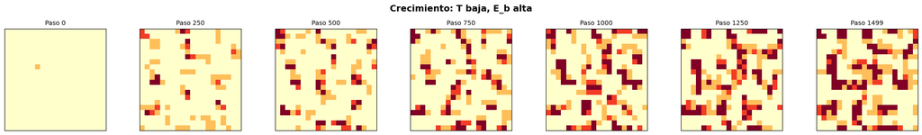

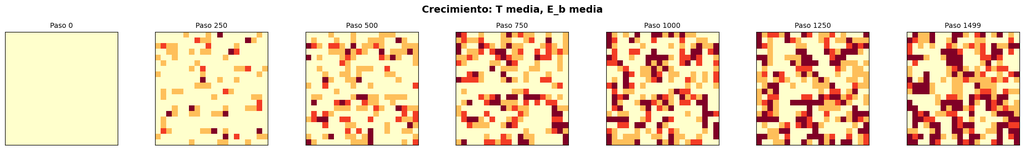

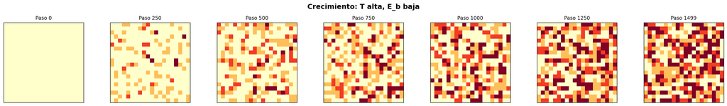

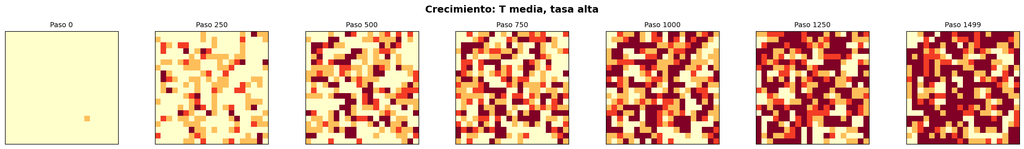

```python
# Visualización de etapas de crecimiento
for cond_name, result in results_t3.items():
    snapshots = result['snapshots']
    n_snap = len(snapshots)
    fig, axes = plt.subplots(1, n_snap, figsize=(3*n_snap, 3))
    fig.suptitle(f'Crecimiento: {cond_name}', fontsize=14, fontweight='bold')

    for idx, (step, grid) in enumerate(snapshots):
        ax = axes[idx] if n_snap > 1 else axes
        im = ax.imshow(grid, cmap='YlOrRd', vmin=0, vmax=3, origin='lower')
        ax.set_title(f'Paso {step}', fontsize=10)
        ax.set_xticks([])
        ax.set_yticks([])

    plt.tight_layout()
    plt.savefig(f'tarea3_growth_{cond_name.replace(" ","_").replace(",","")}.png',
                dpi=150, bbox_inches='tight')
    plt.show()
```

### 3.2 Comparación de Cobertura y Rugosidad

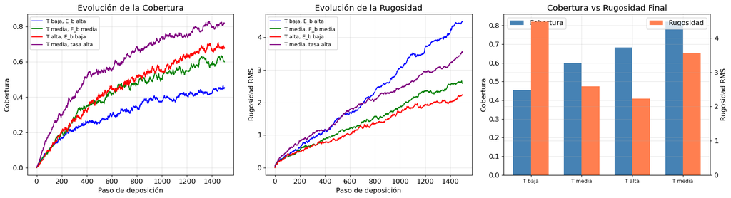

```python
# Comparación de cobertura y rugosidad
fig, axes = plt.subplots(1, 3, figsize=(18, 5))
colors_t3 = ['blue', 'green', 'red', 'purple']

# Panel 1: Cobertura vs paso
ax = axes[0]
for i, (name, result) in enumerate(results_t3.items()):
    ax.plot(result['coverages'], color=colors_t3[i], linewidth=1.5, label=name)
ax.set_xlabel('Paso de deposición')
ax.set_ylabel('Cobertura')
ax.set_title('Evolución de la Cobertura')
ax.legend(fontsize=9)

# Panel 2: Rugosidad vs paso
ax = axes[1]
for i, (name, result) in enumerate(results_t3.items()):
    ax.plot(result['roughnesses'], color=colors_t3[i], linewidth=1.5, label=name)
ax.set_xlabel('Paso de deposición')
ax.set_ylabel('Rugosidad RMS')
ax.set_title('Evolución de la Rugosidad')
ax.legend(fontsize=9)

# Panel 3: Configuraciones finales comparadas
ax = axes[2]
names = list(results_t3.keys())
covs = [results_t3[n]['coverages'][-1] for n in names]
roughs = [results_t3[n]['roughnesses'][-1] for n in names]
x = np.arange(len(names))
width = 0.35
bars1 = ax.bar(x - width/2, covs, width, label='Cobertura', color='steelblue')
ax2 = ax.twinx()
bars2 = ax2.bar(x + width/2, roughs, width, label='Rugosidad', color='coral')
ax.set_xticks(x)
ax.set_xticklabels([n.split(',')[0] for n in names], fontsize=9)
ax.set_ylabel('Cobertura')
ax2.set_ylabel('Rugosidad RMS')
ax.set_title('Cobertura vs Rugosidad Final')
ax.legend(loc='upper left')
ax2.legend(loc='upper right')

plt.tight_layout()
plt.savefig('tarea3_comparacion.png', dpi=150, bbox_inches='tight')
plt.show()
```

### Análisis Profundo: Nanofabricación por Deposición

#### 2. Efecto de la Temperatura

$$D_{\text{sup}} = D_0 \exp\left(-\frac{E_d}{k_B T}\right)$$

- **T baja:** Difusión superficial limitada → los átomos quedan donde aterrizan → **alta rugosidad**, morfología tipo "hit-and-stick". Esto produce películas amorfas o policristalinas.
- **T alta:** Alta difusión → los átomos migran a sitios de menor energía → **capas más uniformes** pero posible desorción (re-evaporación).
- **T óptima:** Balance entre movilidad suficiente y baja desorción → crecimiento epitaxial de alta calidad.

#### 4. Efecto de la Tasa de Deposición

- **Tasa alta:** La llegada rápida de átomos no da tiempo a la difusión → se forman multicapas y mayor rugosidad. Esto es análogo al crecimiento MBE a alto flujo.
- **Tasa baja:** Más tiempo para la reorganización superficial → mejor calidad cristalina.

#### 5. Conexión con Técnicas Experimentales

| Técnica | Analogía en simulación |
| --- | --- |
| **MBE** (Molecular Beam Epitaxy) | Deposición átomo por átomo con control preciso |
| **PVD** (Physical Vapor Deposition) | Alta tasa de deposición, menor control |
| **ALD** (Atomic Layer Deposition) | Deposición capa por capa con reacciones químicas |

En la práctica, los parámetros de deposición se optimizan mediante simulaciones como esta antes de realizar experimentos costosos en el laboratorio.

## Conclusiones Generales

1. La **Dinámica Molecular** proporciona información detallada sobre la dinámica y estructura de sistemas a escala nanométrica, con sensibilidad directa a la temperatura.
2. El método **Monte Carlo** ofrece una alternativa eficiente para calcular propiedades de equilibrio, especialmente útil cuando no se requiere información dinámica.
3. Las simulaciones de **nanofabricación** demuestran cómo parámetros como temperatura, energía de enlace y tasa de deposición controlan la morfología de películas delgadas, información esencial para el diseño de nanodispositivos.